# Analysis of Loan Data from Prosper

## by Anderson Abi-A Shoh Chama

## Investigation Overview

> In this project, I will explore Loan dataset from Prosper, which contains 113,937 rows and 81 columns. I will pick some of the variables that are related to Default to analyze. Firstly, some data wrangling and cleaning, and then on to EDA with different types of charts to explore relationships between/among variables, and hopefully get significant results from my research.

## Default Loans Percentage

> I created a new variable **Default** based on the loanstatus variable. Here, 1 represents the defaulted loan and 0 represents completed loan.

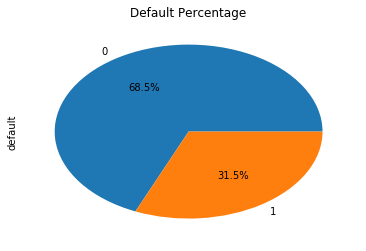

## Borrower Rate by Default

> Borrower rate is the borrower's interest rate for this loan. From the plot, borrower rates are more likely to be highly with default loans.

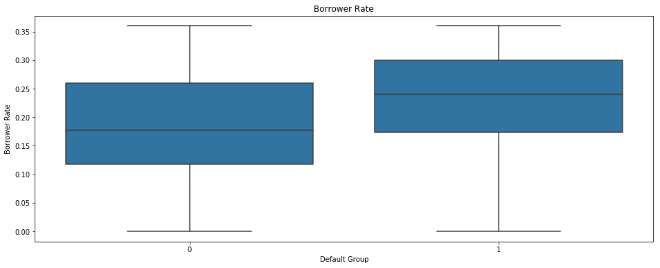

## Default Rate by Income Group

> The highest default rates come from *Not Employed group* and *\$0* group. Also, we also note that the *Not display* group's average default rate is lower than \$0 - \\$49,999.

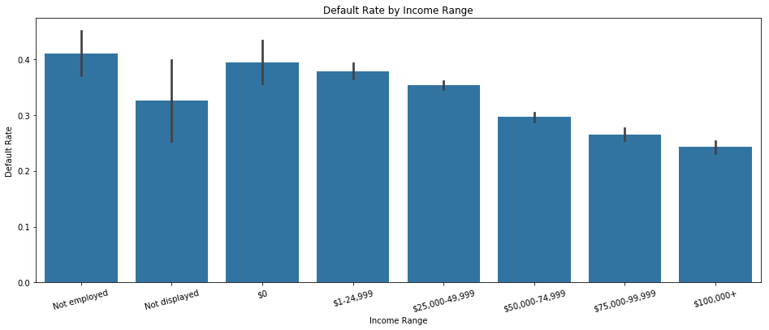

## Credit Score Range Lower by Default Rate

> The is a strong negative correlation between credit score lower range and default rate. However, there is an anomally at creditscorerangelower = 860

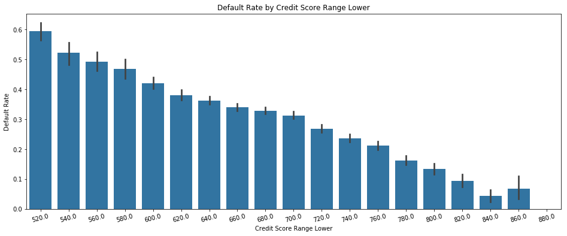

## Borrower Rate by Credit Score Range Lower & Default Rate

> For each credit score, the borrower rate for the default group are more likely to be higher.

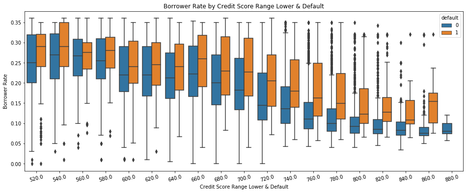